# COVID_universal_healthcare_data_analysis

D. Fritts

2025-09-01

## Introduction

The central question I will attempt to answer in this analysis is **“Does access to universal healthcare affect the COVID case to death ratio?”**. Universal healthcare is often cited as one of the reasons for the success or failure of a country’s health, depending on your political bias. Since COVID was the most significant health crisis of our lives to date, it seems like an interesting question to see if universal healthcare helped countries deal with COVID or not. The way I am measuring this is in the case to death ratio, meaning “of the people who contracted covid, what percent of them passed away?”.

#### Sources

We will be obtaining the covid cases and death data from the John Hopkins COVID data repository, located here: https://github.com/CSSEGISandData/COVID-19/tree/master/csse_covid_19_data/csse_covid_19_time_series. The two datasets we are obtaining for the analysis are: “time_series_covid19_deaths_global.csv” for the deaths and “time_series_covid19_confirmed_global.csv” for the cases.

Our global data set does not include information about which countries do or do not have universal healthcare, so I have obtained it from a third party source: https://worldpopulationreview.com/country-rankings/countries-with-universal-healthcare. I have included this data set as a csv in the repository, called “countries-with-universal-healthcare-2025.csv”. Please make sure this file is in the same directory as the rmd file for proper knitting.

## Data Load and Setup

Setting up environment variables and loading in the relevant libraries.

```r
# Loading in necessary libraries
library(tidyverse)
```

Here we are loading in the two John Hopkins data sets. The first one details the global COVID case numbers for each country on each day. The other deatils the global deaths attributed to COVID for each country on each day.

```r
# For this analysis I am only going to work with the global data.

url_in <- "https://raw.githubusercontent.com/CSSEGISandData/COVID-19/master/csse_covid_19_data/csse_covid_19_time_series/"

file_names <- c(
  "time_series_covid19_confirmed_global.csv",
  "time_series_covid19_deaths_global.csv")

urls <- str_c(url_in, file_names)

global_cases <- read_csv(urls[1])
global_deaths <- read_csv(urls[2])
```

Here we are loading in the Universal Healthcare data from worldpopulationreview, detailing which countries have universal healthcare and which do not.

```r
healthcare <- read_csv("./countries-with-universal-healthcare-2025.csv")
```

## Data Preparation

Here we prepare the COVID datasets. Both the cases and deaths come in wide form, meaning there is a column for each date recorded and a value of the cases or deaths on that day for each country. I will be pivoting those down to long form, meaning that there are two columns: “cases” and “deaths” that represents the occurence of deaths and cases on that day for a given country.

These two datasets, cases and deaths are joined together. Afterwords, the data set containing information about if a country has universal healthcare or not is joined in as well.

Columns are renamed for clarity, and column data types are standardized away from character types.

```r
# Pivoting out global cases and removing Lat and Long
global_cases_tidy <- global_cases %>% pivot_longer(cols = -c('Province/State', 'Country/Region', 'Lat', 'Long'), names_to = "date", values_to = "cases") %>% select(-c(Lat, Long))

# Pivoting out global deaths and removing Lat and Long
global_deaths_tidy <- global_deaths %>% pivot_longer(cols = -c('Province/State', 'Country/Region', 'Lat', 'Long'), names_to = "date", values_to = "deaths") %>% select(-c(Lat, Long))

# Joining global cases and deaths, cleaning up column names and changing date(string) to date (date)
global <- global_cases_tidy %>%
  full_join(global_deaths_tidy) %>%
  rename(Country_Region = 'Country/Region',
         Province_State = 'Province/State') %>%
  mutate(date = mdy(date))
# Joining universal healthcare data into the covid dataset.
global_hc <- global %>%
  left_join(select(healthcare, country, CountriesWithUniversalHealthcare),
            by = c("Country_Region" = "country")) %>% select(-c("Province_State")) %>%
  mutate(Country_Region = as.factor(Country_Region),
         CountriesWithUniversalHealthcare = replace_na(CountriesWithUniversalHealthcare, "No"),
         CountriesWithUniversalHealthcare = as.factor(CountriesWithUniversalHealthcare)) %>%
  rename(has_uhc = CountriesWithUniversalHealthcare, country = Country_Region)

summary(global_hc)
```

```
##            country            date                cases
##  China         : 38862   Min.   :2020-01-22   Min.   :        0
##  Canada        : 18288   1st Qu.:2020-11-02   1st Qu.:      680
##  United Kingdom: 17145   Median :2021-08-15   Median :    14429
##  France        : 13716   Mean   :2021-08-15   Mean   :   959384
##  Australia     :  9144   3rd Qu.:2022-05-28   3rd Qu.:   228517
##  Netherlands   :  5715   Max.   :2023-03-09   Max.   :103802702
##  (Other)       :227457
##      deaths        has_uhc
##  Min.   :      0   No :154305
##  1st Qu.:      3   Yes:176022
##  Median :    150
##  Mean   :  13380
##  3rd Qu.:   3032
##  Max.   :1123836
##
```

Here we are obtaining the variable we are most concerned with: death_to_case_ratio. death_to_case_ratio is defined by total_deaths / total_cases for a country and given year. A higher death_to_case_ratio indicates that a country had worse outcomes (death) for those who contracted COVID, and the inverse is true for lower death_to_case_ratios.

```r
yearly_ratios <- global_hc %>%
  filter(cases > 0 & deaths > 0) %>%
  group_by(country, year = year(date)) %>%
  summarise(total_cases = max(cases),
            total_deaths = max(deaths),
            has_uhc = first(has_uhc)) %>%
  mutate(death_to_case_ratio = total_deaths / total_cases) %>%
  arrange(death_to_case_ratio) %>%
  filter(death_to_case_ratio <= 1)
summary(yearly_ratios)
```

```
##                 country         year       total_cases
##  Afghanistan        :  4   Min.   :2020   Min.   :        7
##  Albania            :  4   1st Qu.:2021   1st Qu.:    24825
##  Algeria            :  4   Median :2022   Median :   201785
##  Andorra            :  4   Mean   :2022   Mean   :  2226603
##  Angola             :  4   3rd Qu.:2023   3rd Qu.:  1083377
##  Antigua and Barbuda:  4   Max.   :2023   Max.   :103802702
##  (Other)            :730
##   total_deaths       has_uhc   death_to_case_ratio
##  Min.   :      1.0   No :492   Min.   :0.0001906
##  1st Qu.:    294.2   Yes:262   1st Qu.:0.0073562
##  Median :   2526.5             Median :0.0138431
##  Mean   :  27571.8             Mean   :0.0188263
##  3rd Qu.:  13975.5             3rd Qu.:0.0222132
##  Max.   :1123836.0             Max.   :0.2906146
##
```

## Initial Analysis and Visualization

#### Overall Mean Ratios

First I want to examine the overall trend.

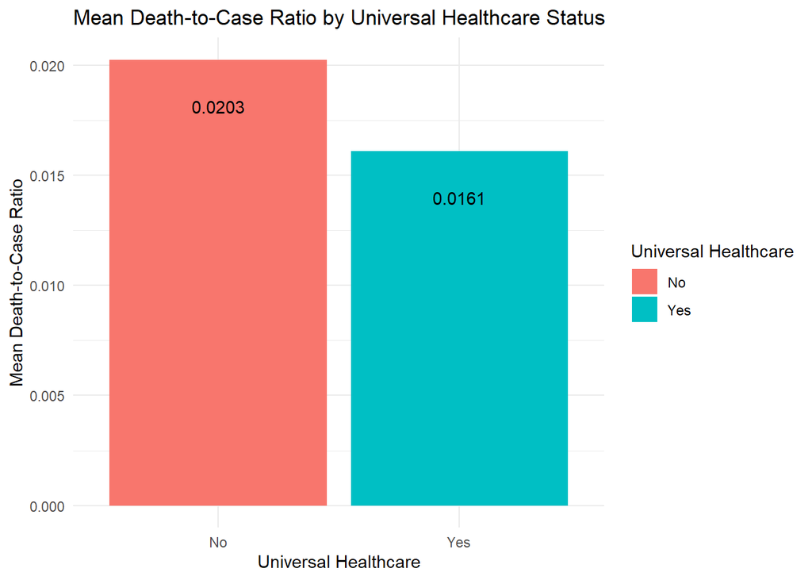

```r
# Summarize mean ratios
overall_ratios_summary <- yearly_ratios %>%
  group_by(has_uhc) %>%
  summarise(mean_ratio = mean(death_to_case_ratio, na.rm = TRUE))

# Plot
ggplot(overall_ratios_summary, aes(x = has_uhc, y = mean_ratio, fill = has_uhc)) +
  geom_bar(stat = "identity") +
  geom_text(aes(label = round(mean_ratio, 4), vjust=4)) +
  labs(title = "Mean Death-to-Case Ratio by Universal Healthcare Status",
       x = "Universal Healthcare",
       y = "Mean Death-to-Case Ratio",
       fill = "Universal Healthcare") +
  theme_minimal()
```

```r
overall_ratios_summary
```

```
## # A tibble: 2 × 2
##   has_uhc mean_ratio
##   <fct>        <dbl>
## 1 No          0.0203
## 2 Yes         0.0161
```

Looking at the graph and summary, on average, it looks like countries with universal healthcare have lower death_to_case_ratios, meaning that their citizens had a lower chance of dying from COVID once they contracted it. However, that overall difference in mean ratios is small, only a difference of ~0.0042. This is just a high level view, so lets dive deeper to obtain a greater understanding of what’s going on here.

#### Yearly Mean Ratios

Here we break out the data by year and show the difference in death to case ratios.

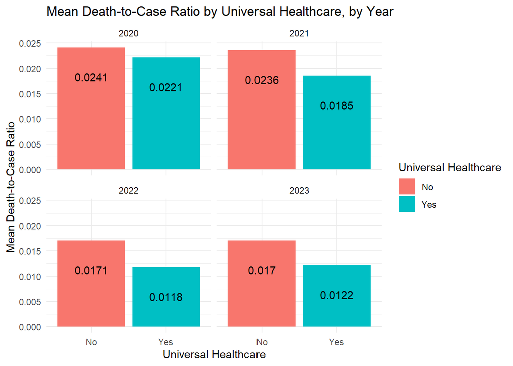

```r
# Summarize mean ratios by has_uhc and year
yearly_ratios_summary <- yearly_ratios %>%
  group_by(has_uhc, year) %>%
  summarise(mean_ratio = mean(death_to_case_ratio, na.rm = TRUE), .groups = "drop")

# Faceted bar plot
ggplot(yearly_ratios_summary, aes(x = has_uhc, y = mean_ratio, fill = has_uhc)) +
  geom_bar(stat = "identity") +
  facet_wrap(~ year) +
  geom_text(aes(label = round(mean_ratio, 4), vjust=4)) +
  labs(title = "Mean Death-to-Case Ratio by Universal Healthcare, by Year",
       x = "Universal Healthcare",
       y = "Mean Death-to-Case Ratio",
       fill = "Universal Healthcare") +
  theme_minimal()
```

```r
yearly_ratios_summary
```

```
## # A tibble: 8 × 3
##   has_uhc  year mean_ratio
##   <fct>   <dbl>      <dbl>
## 1 No       2020     0.0241
## 2 No       2021     0.0236
## 3 No       2022     0.0171
## 4 No       2023     0.0170
## 5 Yes      2020     0.0221
## 6 Yes      2021     0.0185
## 7 Yes      2022     0.0118
## 8 Yes      2023     0.0122
```

## Wilcoxon Test: Comparing Distributions

Since we are interested in comparing distributions, I am going to use the Wilcoxon Rank-Sum test. This allows me to check if two independent groups have the same distrubtion / median. In this case, the two groups are countries with universal healthcare and those without universal healthcare. The distributions in question are the death_to_case_ratios for each group and for each year. The null hypothesis in this test asserts that the distrubtions between the two groups are the same, meaning there is no significant difference between the two groups. If the analysis reveals a p-value <0.05, there is good reason to reject this null hypothesis.

```r
# Wilcoxon test for each year
p_values <- yearly_ratios %>%
  group_by(year) %>%
  summarise(p_value = wilcox.test(death_to_case_ratio ~ has_uhc)$p.value,
            .groups = "drop")

# Print results
print(p_values)
```

```
## # A tibble: 4 × 2
##    year p_value
##   <dbl>   <dbl>
## 1  2020  0.644
## 2  2021  0.0973
## 3  2022  0.0489
## 4  2023  0.0951
```

As you can see, the p-values for each year differ significantly. In 2020, it seems that universal healthcare did not differentiate the two groups significantly - if you will refer back to our yearly graph you can see that this is the year in which the gap between the two was smallest. 2022, on the other hand, does show a p-value <0.05, meaning there is good reason to be beleive that a country having universal healthcare does affect the death to case ratio. In the case of 2021 and 2023, while the p-value is not less than 0.05, it is quite close, being ~0.09. This, combined with the overall trend, suggests to me that there may be something to this - further analysis is needed.

## Linear Model Analysis

Here I will attempt to use a linear model to see if the death_to_case_ratio is a function of a country having universal healthcare and the year. This model hopes to explain the variation in death_to_case_ratio based on whether or not a country has universal healthcare, and the year.

```r
ratios_model <- yearly_ratios %>%
  mutate(has_uhc = as.factor(has_uhc),
         year = as.factor(year))

model <- lm(death_to_case_ratio ~ has_uhc + year, data = ratios_model)
summary(model)
```

```
##
## Call:
## lm(formula = death_to_case_ratio ~ has_uhc + year, data = ratios_model)
##
## Residuals:
##       Min        1Q    Median        3Q       Max
## -0.024110 -0.010288 -0.005065  0.003693  0.265667
##
## Coefficients:
##              Estimate Std. Error t value Pr(>|t|)
## (Intercept)  0.024947   0.001990  12.534  < 2e-16 ***
## has_uhcYes  -0.004305   0.001901  -2.265  0.02382 *
## year2021    -0.001639   0.002606  -0.629  0.52959
## year2022    -0.008201   0.002580  -3.178  0.00154 **
## year2023    -0.008110   0.002580  -3.143  0.00174 **
## ---
## Signif. codes:  0 '***' 0.001 '**' 0.01 '*' 0.05 '.' 0.1 ' ' 1
##
## Residual standard error: 0.02485 on 749 degrees of freedom
## Multiple R-squared:  0.02785,    Adjusted R-squared:  0.02266
## F-statistic: 5.364 on 4 and 749 DF,  p-value: 0.0002911
```

### Interpreting the Model Results

**Residuals** Residuals represent the difference between the actual values and the predicted values - essentially the error in predictions (Actual - Predicted). The residuals have a relatively wide distribution towards the positive end (max: 0.265667), but are tight around the lower end (min: -0.024110 and median: -0.005065). This suggests that there is outlier country+year which has a really high death_to_case ratio, or perhaps a value that the model significantly undershot.

**Coefficients** Intercept (0.0249, p-value=2e-16): The intercept, represents the mean death_to_case_ratio for countries without universal healthcare in the year 2020. This is our baseline ratio, of 2.49%, meaning this is the expected value for a country without universal healthcare in 2020. This is the starting point to which the other coefficients are compared.

has_uhcYes(-0.0043, p < 0.02382): This coefficient is significant at p < 0.05. This means that countries with universal healthcare have, on average, 0.43% lower death_to_case_ratio values than those countries without universal healthcare. The difference between them is not enormous, but having universal healthcare does have a statistically significant impact on lowering death to case rate.

year2021 (-0.0016, p = 0.5296): This coefficient is not significant, as it has a p-value of 0.5296. Meaning that while the average rate was 0.0016 lower than 2020, this could be due to chance.

**Residual Standard Error (RSE) = 0.02485** RSE measures the average deviation of the actual death_to_case_ratio from the model’s predictions. On average, predictions are off by 2.485%. This indicates further unexplained variability.

**R-Squared: Multiple = 0.02785, Adjusted = 0.02266** The R-Square value signifies how much variance is explained in death_to_case_ratios by the model. In this case it is only around 2.5%, meaning that year and whether a country has universal healthcare or not does not explain most of the variation. Other factors such as GPD, region, population size, testing procedures, and vaccination rates likely explain much of the remaining variability.

**F-statistics = 5.364 on 4 and 749 DF, p-value = 0.0002911** Since the p-value is so low, this means that the overall model is statistically significant. This means that the predictors of “has_uhc” and “year” together provide better predictions than a model with no predictors. Combining this fact with the low R-squared value means that, while there is something here, the improvement in prediction capability is modest.

749 DF means that my sample size is ~750. More granularity, perhaps breaking it down by month, may reveal more definite trends.